# 03_Figures_Draft

Arthur M. Albuquerque

June 15, 2021

**In this document, I will only present data regarding the mortality outcome. Thus, positive risk differences mean benefit.**

## Table 1: Overall view of the data

Here, the primary aim is to give an overall view of how many patients are involved in each subgroup and study.

| Study | Control Events | Control Total | Control Risk (%) | Tocilizumab Events | Tocilizumab Total | Tocilizumab Risk (%) |
| --- | --- | --- | --- | --- | --- | --- |
| Not using corticosteroids |  |  |  |  |  |  |
| RECOVERY | 127 | 367 | 35 | 139 | 357 | 39 |
| COVACTA | 10 | 65 | 15 | 29 | 188 | 15 |
| REMAP-CAP | 9 | 36 | 25 | 6 | 37 | 16 |
| Using corticosteroids |  |  |  |  |  |  |
| RECOVERY | 600 | 1721 | 35 | 482 | 1664 | 29 |
| COVACTA | 18 | 79 | 23 | 29 | 106 | 27 |
| REMAP-CAP | 134 | 361 | 37 | 102 | 358 | 28 |
| Simple oxygen only |  |  |  |  |  |  |
| RECOVERY | 214 | 933 | 23 | 180 | 935 | 19 |
| COVACTA | 2 | 44 | 5 | 9 | 78 | 12 |
| CORIMUNO-19 | 8 | 67 | 12 | 7 | 63 | 11 |
| Non-invasive ventilation |  |  |  |  |  |  |
| RECOVERY | 366 | 867 | 42 | 310 | 819 | 38 |
| COVACTA | 12 | 39 | 31 | 18 | 94 | 19 |
| REMAP-CAP | 82 | 273 | 30 | 53 | 242 | 22 |
| Salvarani | 1 | 63 | 2 | 2 | 60 | 3 |
| Invasive mechanical ventilation |  |  |  |  |  |  |
| RECOVERY | 149 | 294 | 51 | 131 | 268 | 49 |
| COVACTA | 14 | 55 | 25 | 31 | 113 | 27 |
| REMAP-CAP | 60 | 124 | 48 | 45 | 108 | 42 |

## Figure 1: Overall view of the data

Here, the primary aim is to visually present our priors and the RECOVERY. I believe it is extremely important to present this data in a figure since they are the foundation underlying the posterior distributions in the next figures. I note that the x axis in Panel B is still “under construction”. I want to maintain the scale on Odds Ratio, but the prior for simple oxygen only is very uncertain, ranging from ~0.49 to ~3.8. So I am trying to simulate an axis break.

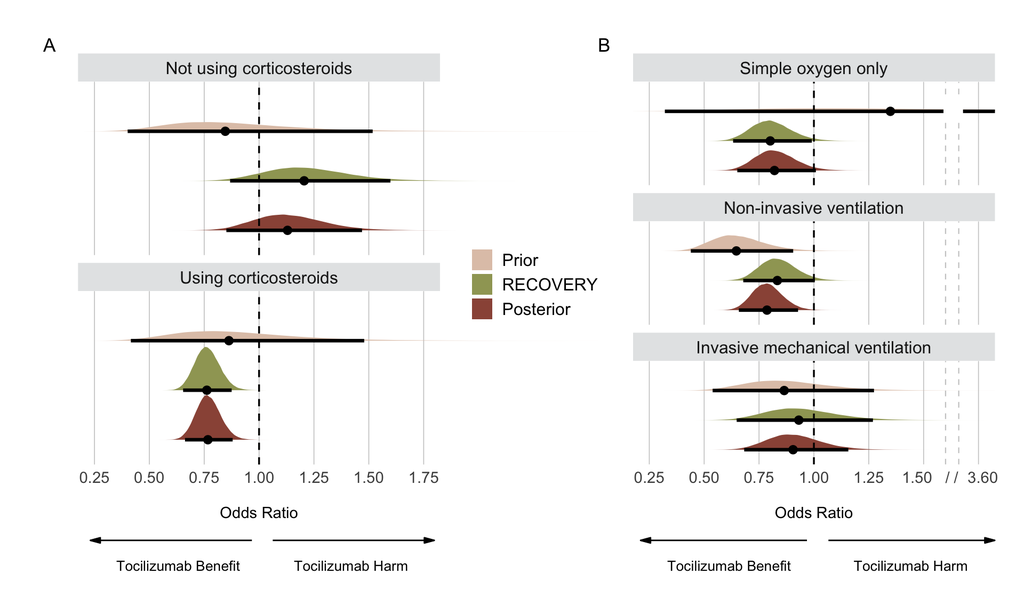

Point estimates depict the median and interval bars depict 95% highest density intervals

Here are the 95% HDIs in *odds ratio* for each distribution from the figure above.

| Distribution | 95% Highest Density Interval Median | 95% Highest Density Interval Lower limit | 95% Highest Density Interval Upper limit |
| --- | --- | --- | --- |
| Not using corticosteroids |  |  |  |
| Prior | 0.85 | 0.44 | 1.60 |
| RECOVERY | 1.21 | 0.89 | 1.63 |
| Posterior | 1.13 | 0.86 | 1.48 |
| Using corticosteroids |  |  |  |
| Prior | 0.86 | 0.47 | 1.59 |
| RECOVERY | 0.76 | 0.66 | 0.88 |
| Posterior | 0.77 | 0.67 | 0.88 |
| Simple oxygen only |  |  |  |
| Prior | 1.35 | 0.50 | 3.85 |
| RECOVERY | 0.80 | 0.64 | 1.00 |
| Posterior | 0.82 | 0.66 | 1.02 |
| Non-invasive ventilation |  |  |  |
| Prior | 0.65 | 0.45 | 0.93 |
| RECOVERY | 0.83 | 0.69 | 1.02 |
| Posterior | 0.79 | 0.66 | 0.93 |
| Invasive mechanical ventilation |  |  |  |
| Prior | 0.86 | 0.56 | 1.31 |
| RECOVERY | 0.93 | 0.67 | 1.31 |
| Posterior | 0.91 | 0.70 | 1.18 |

## Figure 2: Posterior distributions

In my opinion, this is the most important figure. I decided not to use tables, because there are too much data and Panel B and D seem to handle well this great amount of data.

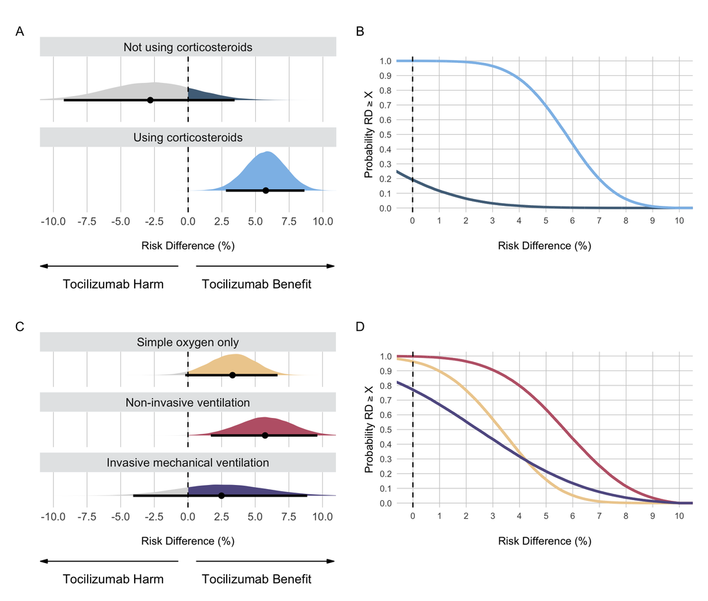

Panels A and C: Point estimates depict the median. Interval bars depict the 80% and 95% highest density intervals. Panels B and D: Cumulative posterior distributions correspond to the probabilities that the risk difference (RD) is greater than or equal to the effect size on the X‐axis.

| Subgroup | 95% Highest Density Interval Median | 95% Highest Density Interval Lower limit | 95% Highest Density Interval Upper limit | Probability of Risk Difference ≥ X% Pr(≥ 0%) | Probability of Risk Difference ≥ X% Pr(≥ 1%) | Probability of Risk Difference ≥ X% Pr(≥ 2%) | Probability of Risk Difference ≥ X% Pr(≥ 3%) |
| --- | --- | --- | --- | --- | --- | --- | --- |
| Use of corticosteroids |  |  |  |  |  |  |  |
| Not using | -2.8 | -9.2 | 3.5 | 18.9 | 11.5 | 6.3 | 3.1 |
| Using | 5.8 | 2.8 | 8.6 | 100.0 | 99.9 | 99.3 | 96.5 |
| Respiratory support |  |  |  |  |  |  |  |
| Simple oxygen only | 3.3 | -0.2 | 6.7 | 96.2 | 89.7 | 76.6 | 57.0 |
| Non-invasive ventilation | 5.7 | 1.7 | 9.6 | 99.7 | 98.9 | 96.4 | 90.6 |
| Invasive mechanical ventilation | 2.5 | -4.1 | 8.9 | 77.3 | 67.3 | 55.8 | 44.0 |

## Figure 3: Posterior distributions; Sensitivity analysis of using different priors

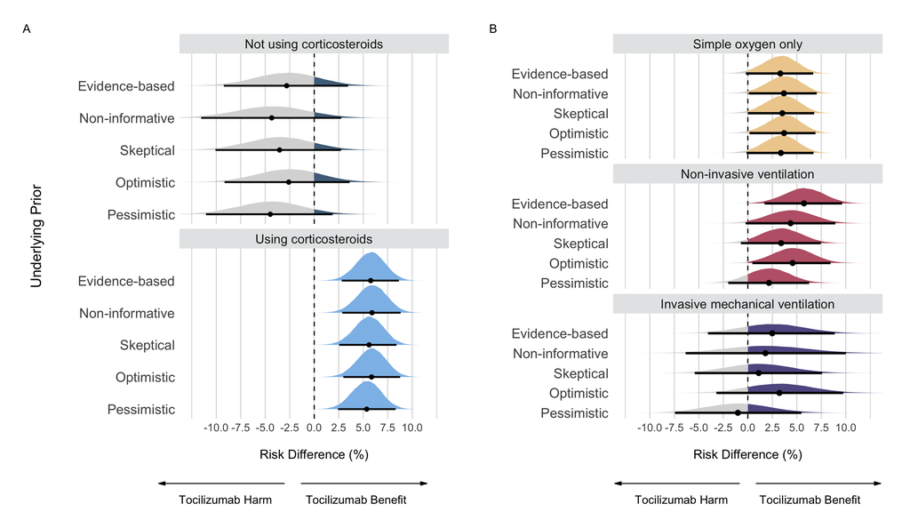

## Supplementary Tables 3 and 4: Posterior distributions; Sensitivity analysis using different priors

This table complements Figure 3.

| Underlying Prior | 95% Highest Density Interval Median | 95% Highest Density Interval Lower limit | 95% Highest Density Interval Upper limit |
| --- | --- | --- | --- |
| Not using corticosteroids |  |  |  |
| Evidence-based | -2.8 | -9.2 | 3.5 |
| Non-informative | -4.3 | -11.5 | 2.7 |
| Skeptical | -3.5 | -10.1 | 2.7 |
| Optimistic | -2.6 | -9.2 | 3.6 |
| Pessimistic | -4.5 | -11.0 | 1.9 |
| Using corticosteroids |  |  |  |
| Evidence-based | 5.8 | 2.8 | 8.6 |
| Non-informative | 5.9 | 2.9 | 8.8 |
| Skeptical | 5.6 | 2.6 | 8.4 |
| Optimistic | 5.9 | 3.0 | 8.8 |
| Pessimistic | 5.4 | 2.4 | 8.3 |
| Simple oxygen only |  |  |  |
| Evidence-based | 3.3 | -0.2 | 6.7 |
| Non-informative | 3.7 | 0.1 | 7.0 |
| Skeptical | 3.5 | 0.0 | 6.8 |
| Optimistic | 3.7 | 0.2 | 6.9 |
| Pessimistic | 3.4 | -0.1 | 6.7 |
| Non-invasive ventilation |  |  |  |
| Evidence-based | 5.7 | 1.7 | 9.6 |
| Non-informative | 4.4 | -0.2 | 8.9 |
| Skeptical | 3.4 | -0.7 | 7.4 |
| Optimistic | 4.6 | 0.5 | 8.4 |
| Pessimistic | 2.2 | -2.0 | 6.3 |
| Invasive mechanical ventilation |  |  |  |
| Evidence-based | 2.5 | -4.1 | 8.9 |
| Non-informative | 1.8 | -6.4 | 10.0 |
| Skeptical | 1.1 | -5.4 | 7.6 |
| Optimistic | 3.2 | -3.2 | 9.7 |
| Pessimistic | -1.0 | -7.4 | 5.5 |

| Underlying Prior | Propability of Harm Pr(< -3%) | Propability of Harm Pr(< -2%) | Propability of Harm Pr(< -1%) | Probability of Benefit Pr(> 0%) | Probability of Benefit Pr(> 1%) | Probability of Benefit Pr(> 2%) | Probability of Benefit Pr(> 3%) |
| --- | --- | --- | --- | --- | --- | --- | --- |
| Not using corticosteroids |  |  |  |  |  |  |  |
| Evidence-based | 47.8 | 59.9 | 71.4 | 18.9 | 11.5 | 6.3 | 3.1 |
| Non-informative | 64.3 | 74.2 | 82.3 | 11.4 | 6.8 | 3.7 | 1.9 |
| Skeptical | 56.6 | 68.0 | 78.3 | 13.6 | 7.9 | 4.0 | 1.8 |
| Optimistic | 45.3 | 57.4 | 69.0 | 20.8 | 12.9 | 7.3 | 3.8 |
| Pessimistic | 67.4 | 77.6 | 85.8 | 8.3 | 4.4 | 2.1 | 0.9 |
| Using corticosteroids |  |  |  |  |  |  |  |
| Evidence-based | 0.0 | 0.0 | 0.0 | 100.0 | 99.9 | 99.3 | 96.5 |
| Non-informative | 0.0 | 0.0 | 0.0 | 100.0 | 99.9 | 99.3 | 96.8 |
| Skeptical | 0.0 | 0.0 | 0.0 | 100.0 | 99.9 | 99.0 | 95.6 |
| Optimistic | 0.0 | 0.0 | 0.0 | 100.0 | 99.9 | 99.4 | 97.0 |
| Pessimistic | 0.0 | 0.0 | 0.0 | 100.0 | 99.8 | 98.6 | 93.9 |
| Simple oxygen only |  |  |  |  |  |  |  |
| Evidence-based | 0.1 | 0.3 | 1.1 | 96.2 | 89.7 | 76.6 | 57.0 |
| Non-informative | 0.1 | 0.2 | 0.8 | 97.4 | 92.6 | 82.2 | 64.8 |
| Skeptical | 0.0 | 0.2 | 0.8 | 97.2 | 91.9 | 80.3 | 61.7 |
| Optimistic | 0.0 | 0.1 | 0.6 | 97.8 | 93.2 | 83.0 | 65.5 |
| Pessimistic | 0.1 | 0.2 | 1.0 | 96.6 | 90.4 | 77.7 | 58.4 |
| Non-invasive ventilation |  |  |  |  |  |  |  |
| Evidence-based | 0.0 | 0.0 | 0.1 | 99.7 | 98.9 | 96.4 | 90.6 |
| Non-informative | 0.1 | 0.4 | 1.3 | 96.7 | 92.1 | 84.0 | 71.6 |
| Skeptical | 0.1 | 0.6 | 1.9 | 94.6 | 87.3 | 74.7 | 57.6 |
| Optimistic | 0.0 | 0.1 | 0.4 | 98.6 | 95.7 | 89.3 | 77.7 |
| Pessimistic | 0.8 | 2.6 | 6.8 | 84.5 | 70.7 | 52.9 | 34.5 |
| Invasive mechanical ventilation |  |  |  |  |  |  |  |
| Evidence-based | 5.0 | 8.9 | 14.7 | 77.3 | 67.3 | 55.8 | 44.0 |
| Non-informative | 12.6 | 18.3 | 25.2 | 66.7 | 57.6 | 48.1 | 38.8 |
| Skeptical | 10.9 | 17.5 | 26.3 | 63.1 | 51.3 | 39.6 | 28.6 |
| Optimistic | 3.1 | 5.8 | 10.2 | 83.3 | 74.6 | 64.1 | 52.6 |
| Pessimistic | 27.5 | 38.3 | 50.2 | 38.0 | 27.2 | 18.2 | 11.3 |